# Statistical report for ACASA-TAVI

AntiCoagulation versus AcetylSalicylic Acid after Transcatheter Aortic Valve Implantation

C. Cunen

13 juni 2026

# 1 Introduction

This report summarises the currently available baseline data with emphasis on clinical status, imaging assessments, and prior treatments that may influence subsequent outcomes.

The aim of this document is to produce tables and figures to be included into the article as requested by email from Merete Hetland 10 December 2019. The analyses are prespecified in the Statistical Analysis Plan (SAP) dated 2nd of September 2019, and the locked database with an update received on the 10th of December dated 26th of October 2019.

## 1.2 Data preparations

The data have been further prepared in accordance with the SAP, except for the imputation of missing baseline Body Mass Index (BMI) for two trial subjects. They have been imputed with the median BMI value among all other ITT subjects. This imputation is not described in the SAP.

## 1.3 Specifications to the analyses

# 2 Patient enrolment and disposition

## 2.1 Trial population

The following table summarizes the number of patients that were screened (?), that were eligible and randomized, that received the treatment and that were lost to follow-up, as well as the number of patients included in the analyses. This table should be used to fill in the CONSORT diagram (??).

Table 2.1: Counts

| description | n |
| --- | --- |
| Assessed at screening |  |
| Eligible at screening |  |
| Ineligible at screening |  |
| Eligible and randomised | 359 |
| Eligible not randomised |  |
| Randomized but ineligible | 1 |
| Non-completers | 24 |
| Randomised and FAS | 360 |
| Randomised and FAS with primary efficacy endpoint | 334 |
| Randomised and FAS with primary safety endpoint | 343 |

## 2.2 Patient disposition (reasons for non-completion)

Overview of study completion and reasons for non-completion. The counts of “Study completed” which are neither “Yes” nor “No” are participants who have not had their final visit yet.

Table 2.2: Overview of study completion and reasons for non-completion

|  | DOAC | ASA | Total |
| --- | --- | --- | --- |
| Number of randomised participants | 180 | 180 | 360 |
| Study completed |  |  |  |
| No | 14 | 10 | 24 |
| Yes | 166 | 170 | 336 |
| Reason for discontinuation |  |  |  |
| Voluntary discontinuation by patient | 4 | 5 | 9 |
| Incorrect randomisation | 1 | 0 | 1 |
| Non-compliance | 1 | 0 | 1 |
| Death | 7 | 5 | 12 |
| Other | 1 | 0 | 1 |

## 2.3 Timing of end of study, withdrawals and follow ups

Time from randomisation to end of study and time from randomisation to withdrawal/lost to follow-up is summarized by median and min-max, overall and by treatment group.

Table 2.3: Length of study by treatment groups

|  | DOAC | ASA | Overall |
| --- | --- | --- | --- |
| All participants | 361 (0-510) | 357 (1-440) | 358.5 (0-510) |
| Non-completers | 31 (0-363) | 183.5 (1-271) | 121 (0-363) |

## 2.4 Protocol deviations

Number of major and minor protocol deviations, summarized by treatment group with details of type of deviation provided.

Table 2.4: Number of minor protocol deviations

| Treatment | Category of PD | n |
| --- | --- | --- |
| DOAC | Incorrect treatment and/or dose | 2 |
| DOAC | Prohibited concomitant medication | 3 |
| DOAC | Failure to collect important data | 6 |
| DOAC | Serious breach - Other | 1 |
| DOAC | Other | 10 |
| ASA | Prohibited concomitant medication | 3 |
| ASA | Failure to collect important data | 4 |
| ASA | Serious breach - SAE notification / safety procedure | 2 |
| ASA | Other | 8 |

There are currently no PD that are categorised as “major”.

Table 2.5: Number of major protocol deviations

| Treatment | Category of PD | n |
| --- | --- | --- |

## 2.5 Adherence to allocated treatment

Number of patients participants switching between ASA and DOAC or stopping the treatment altogether (so far - final data could reveal more switches), by treatment group and in total.

Table 2.6: Number of participants switching or stopping.

|  | No change in study drug | Switching | Stopping |
| --- | --- | --- | --- |
| DOAC | 156 | 17 | 7 |
| ASA | 157 | 19 | 4 |
| Total | 313 | 36 | 11 |

## 2.6 Analysis sets

The FAS includes all participants. The SAS is the same as the FAS. The PP includes all participants except – non-completers that did not die (voluntary discontinuation mostly) – participants with important protocol deviations – participants switching between ASA and DOAC or stopping the treatment altogether.

Table 2.7: Number of participants in the different analysis sets.

|  | Full analysis set | Per protocol set |
| --- | --- | --- |
| DOAC | 180 | 152 |
| ASA | 180 | 153 |
| Total | 360 | 305 |

# 3 Demographics and baseline characteristics

## 3.1 Table for abstract (May 2026)

Table 3.1: Baseline characteristics for all 360 participants. Continuous variables are summarised by mean (SD), or by median (IQR) as indicated.

| Age (years) | 74.5 (3.7) |
| --- | --- |
| Sex, female | 37% |
| Body mass index (kg/m^2) | 28.1 (4.7) |
| Coronary artery disease | 24% |
| Hypertension | 71% |
| Diabetes mellitus | 28% |
| Previous stroke | 11% |
| Permanent pacemaker | 2% |
| Chronic obstructive pulmonary disease | 14% |
| Troponin T (ng/L) | 16 (11 - 28) |
| NT-proBNP (ng/L) | 413 (197 - 812) |
| Glomerular filtration rate (mL/min/1 1.73 m^2) | 75 (18.4) |
| Pre-TAVI echocardiography parameters |  |
| Left ventricular ejection fraction (%) | 53.6 (7.7) |
| Aortic valve mean gradient (mmHg) | 49.6 (12.6) |
| Aortic valvular area (cm^2) | 0.8 (0.2) |
| Procedural characteristics |  |
| Balloon-expanded valve | 71% |
| Self-expandable valve | 29% |

## 3.2 Demographics and medical history

Table 3.2: Demographics and medical history.

| Characteristic | DOAC(n=180) | ASA(n=180) | Overall (n=360) |
| --- | --- | --- | --- |
| Age (years) | 74.4 (3.7) | 74.5 (3.7) | 74.5 (3.7) |
| Sex, n (%) |  |  |  |
| Male | 115 (63.9%) | 111 (61.7%) | 226 (62.8%) |
| Female | 65 (36.1%) | 69 (38.3%) | 134 (37.2%) |
| Hypertension, n (%) |  |  |  |
| Yes | 124 (70.9%) | 126 (72%) | 250 (71.4%) |
| Missing | 5 (2.8%) | 5 (2.8%) | 10 (2.8%) |
| Coronary artery disease, n (%) |  |  |  |
| Yes | 36 (20.6%) | 47 (26.9%) | 83 (23.7%) |
| Missing | 5 (2.8%) | 5 (2.8%) | 10 (2.8%) |
| Diabetes mellitus, n (%) |  |  |  |
| Yes | 54 (30.9%) | 45 (25.7%) | 99 (28.3%) |
| Missing | 5 (2.8%) | 5 (2.8%) | 10 (2.8%) |
| Chronic obstructive pulmonary disease, n (%) |  |  |  |
| Yes | 26 (14.9%) | 22 (12.6%) | 48 (13.7%) |
| Missing | 5 (2.8%) | 5 (2.8%) | 10 (2.8%) |
| Previous stroke, n (%) |  |  |  |
| Yes | 19 (10.9%) | 21 (12%) | 40 (11.4%) |
| Missing | 5 (2.8%) | 5 (2.8%) | 10 (2.8%) |
| Permanent pacemaker |  |  |  |
| Yes | 5 (2.9%) | 3 (1.7%) | 8 (2.3%) |
| Missing | 5 (2.8%) | 5 (2.8%) | 10 (2.8%) |
| Smoking status, n (%) |  |  |  |
| Never smoked | 59 (32.8%) | 66 (36.7%) | 125 (34.7%) |
| Has stopped | 94 (52.2%) | 91 (50.6%) | 185 (51.4%) |
| Sometimes | 1 (0.6%) | 1 (0.6%) | 2 (0.6%) |
| Daily | 26 (14.4%) | 22 (12.2%) | 48 (13.3%) |

## 3.3 Vital signs and physical characteristics at baseline

Table 3.3: Vital signs and physical characteristics at baseline.

| Characteristic | DOAC(n=180) | ASA(n=180) | Overall (n=360) |
| --- | --- | --- | --- |
| Weight (kg) | 84.3 (16.2) | 84.9 (15.9) | 84.6 (16) |
| Height (cm) | 173.8 (9.3) | 173 (9) | 173.4 (9.1) |
| Body mass index (kg/m2) | 27.9 (4.9) | 28.3 (4.5) | 28.1 (4.7) |
| Systolic blood pressure (mmHg) | 137 (19.1) | 143.6 (22) | 140.3 (20.8) |
| Diastolic blood pressure (mmHg) | 71.9 (9.8) | 71.9 (10.4) | 71.9 (10.1) |
| Body temperature (C) | 36.7 (0.4) | 36.7 (0.4) | 36.7 (0.4) |
| Pulse rate (beats/min) | 74.7 (14.6) | 73 (11.6) | 73.8 (13.2) |
| Respiratory rate (breaths/min) | 16.9 (2.9) | 16.8 (2.2) | 16.8 (2.5) |
| Mini-Cog |  |  |  |
| Signs of cognitive impairment (0-2) | 15 (9.3%) | 11 (6.9%) | 26 (8.1%) |
| No cognitive impairment (3-5) | 147 (90.7%) | 148 (93.1%) | 295 (91.9%) |
| Missing | 18 (10%) | 21 (11.7%) | 39 (10.8%) |
| Five times sit-to-stand |  |  |  |
| < 15 sec | 115 (83.3%) | 109 (79.6%) | 224 (81.5%) |
| >= 15 sec | 23 (16.7%) | 28 (20.4%) | 51 (18.5%) |
| Missing | 42 (23.3%) | 43 (23.9%) | 85 (23.6%) |
| Frailty, n (%) |  |  |  |
| Robust | 75 (41.7%) | 90 (50%) | 165 (45.8%) |
| Pre-frail | 59 (32.8%) | 43 (23.9%) | 102 (28.3%) |
| Frail | 0 (0%) | 0 (0%) | 0 (0%) |
| Missing | 46 (25.6%) | 47 (26.1%) | 93 (25.8%) |

## 3.4 Clinical chemistry and hematology at baseline

Table 3.4: Some results related to clinical chemistry and hematology at baseline.

| Characteristic | DOAC(n=180) | ASA(n=180) | Overall (n=360) |
| --- | --- | --- | --- |
| Hemoglobin | 13.4 (1.6) | 13.7 (1.6) | 13.6 (1.6) |
| Platelets | 220.1 (61.7) | 232.9 (67) | 226.5 (64.7) |
| Leukocytes | 7.2 (6.1 - 8.6) | 7.4 (6.5 - 8.7) | 7.3 (6.3 - 8.7) |
| International Normalized Ratio (INR) | 1.1 (0.1) | 1 (0.1) | 1.1 (0.1) |
| Sodium | 139.5 (2.7) | 139.6 (2.8) | 139.6 (2.7) |
| Potassium | 4.1 (0.4) | 4 (0.4) | 4.1 (0.4) |
| ALT | 25.3 (13.3) | 27.6 (13.9) | 26.4 (13.6) |
| Cardiac troponin T | 17 (11.8 - 27.8) | 15 (11 - 28) | 16 (11 - 28) |
| NT-proBNP | 431 (216 - 815) | 372 (177 - 779) | 413 (197 - 812) |
| GFR | 73.6 (19.6) | 76.3 (17.1) | 75 (18.4) |
| Glucose | 6.8 (2) | 6.8 (2.2) | 6.8 (2.1) |
| Glycated haemoglobin (HbA1c) | 42.2 (9.3) | 42 (9.9) | 42.1 (9.6) |
| Triglycerides | 1.6 (0.9) | 1.5 (0.7) | 1.5 (0.8) |
| Missing | 6 (3.3%) | 4 (2.2%) | 10 (2.8%) |
| Total cholesterol | 4.2 (1.1) | 4.3 (1.1) | 4.2 (1.1) |
| HDL cholesterol | 1.4 (0.4) | 1.5 (0.5) | 1.4 (0.5) |
| LDL cholesterol | 2.2 (0.9) | 2.3 (0.9) | 2.3 (0.9) |
| Creatinine | 92.2 (46.8) | 84.8 (29.4) | 88.5 (39.2) |
| Albumin | 42.7 (3.8) | 43 (2.8) | 42.9 (3.3) |
| Missing | 6 (3.3%) | 4 (2.2%) | 10 (2.8%) |
| Bilirubin | 8.9 (4.5) | 9.9 (5.6) | 9.4 (5.1) |
| Missing | 6 (3.3%) | 4 (2.2%) | 10 (2.8%) |
| CRP | 1.6 (0.8 - 4) | 1.4 (0.7 - 3.3) | 1.5 (0.8 - 3.8) |

## 3.5 Echocardiography pre-TAVI and at baseline

Table 3.5: Some echocardiography parameters pre-TAVI.

| Characteristic | DOAC(n=180) | ASA(n=180) | Overall (n=360) |
| --- | --- | --- | --- |
| Aortic valve mean gradient (mmHg) | 49.4 (13.2) | 49.9 (12) | 49.6 (12.6) |
| LVOT (mm) | 22.7 (1.8) | 22.3 (1.9) | 22.5 (1.9) |
| Presence of low-flow low-gradient | 9 (5.3%) | 9 (5.3%) | 18 (5.3%) |
| Left ventricular ejection fraction (%) | 52.9 (7.6) | 54.4 (7.8) | 53.6 (7.7) |
| Left ventricular global longitudinal strain (%) | -15.2 (3.4) | -16.4 (8.9) | -15.8 (6.7) |
| Stroke volume (mL) | 83.7 (19.8) | 86 (22.5) | 84.9 (21.2) |
| Stroke volume index (mL per m^2) | 40.5 (12.6) | 41.1 (14.1) | 40.8 (13.3) |
| Aortic valvular area (cm^2) | 0.8 (0.2) | 0.8 (0.2) | 0.8 (0.2) |
| Aortic valve regurgitation | 108 (63.5%) | 105 (61.4%) | 213 (62.5%) |
| Missing echocardiography | 9 (5%) | 9 (5%) | 18 (5%) |

Table 3.6: Some echocardiography parameters at baseline (post-TAVI).

| Characteristic | DOAC(n=180) | ASA(n=180) | Overall (n=360) |
| --- | --- | --- | --- |
| Aortic valve mean gradient (mmHg) | 13 (4.9) | 13.1 (4.7) | 13.1 (4.8) |
| LVOT (mm) | 21.4 (2) | 21.2 (2) | 21.3 (2) |
| Presence of low-flow low-gradient | 24 (19%) | 22 (17.2%) | 46 (18.1%) |
| Left ventricular ejection fraction (%) | 57.7 (9) | 55.9 (12) | 56.8 (10.7) |
| Left ventricular global longitudinal strain (%) | -15.7 (3.4) | -15.6 (3.4) | -15.6 (3.4) |
| Stroke volume (mL) | 83 (14.7) | 82.8 (20.4) | 82.9 (17.7) |
| Stroke volume index (mL per m^2) | 41.3 (7) | 41.3 (9.2) | 41.3 (8.2) |
| Aortic valvular area (cm^2) | 1.9 (0.4) | 1.9 (0.5) | 1.9 (0.4) |
| Aortic valve regurgitation | 41 (32.5%) | 40 (31.2%) | 81 (31.9%) |
| Missing echocardiography | 58 (32.2%) | 55 (30.6%) | 113 (31.4%) |

## 3.6 Characteristics of the TAVI procedure

Table 3.7: Characteristics of the TAVI procedure.

| Characteristic | DOAC(n=180) | ASA(n=180) | Overall (n=360) |
| --- | --- | --- | --- |
| TAVI valve type, n (%) |  |  |  |
| Balloon-expanded | 130 (72.6%) | 126 (70%) | 256 (71.3%) |
| Self-expandable | 49 (27.4%) | 54 (30%) | 103 (28.7%) |
| TAVI post-dilatation, n (%) |  |  |  |
| Yes | 13 (7.3%) | 20 (11.1%) | 33 (9.2%) |
| No | 166 (92.7%) | 160 (88.9%) | 326 (90.8%) |
| TAVI supra-valvular prothesis position, n (%) |  |  |  |
| Yes | 46 (25.7%) | 54 (30%) | 100 (27.9%) |
| No | 133 (74.3%) | 126 (70%) | 259 (72.1%) |
| Ascending aorta diameter (mm) | 30.5 (4) | 29.6 (3.8) | 30.1 (3.9) |
| Missing | 0 (0%) | 0 (0%) | 0 (0%) |

## 3.7 Change in baseline characteristics

> Some baseline variables are measured again at 12 months. Do you want a table looking at the change in these values? Not here maybe

# 4 Primary endpoints

## 4.1 Primary efficacy endpoint

### 4.1.1 Descriptive statistics

Also by site?

Table 4.1: Descriptive statistics for HALT (primary efficacy endpoint). Counts and proportions.

|  | DOAC | ASA | Overall |
| --- | --- | --- | --- |
| No thickening | 127 | 133 | 260 |
| <=25% of leaflet | 20 | 16 | 36 |
| >25-50 % of leaflet | 13 | 9 | 22 |
| >50-75 % of lealet | 2 | 5 | 7 |
| >75 % of leaflet | 3 | 6 | 9 |
| Missing HALT | 15 | 11 | 26 |
| Death | 7 | 5 | 12 |
| Total HALT | 38 (23%) | 36 (21.3%) | 74 (22.2%) |
| Total HALT & Death | 45 (26.2%) | 41 (23.6%) | 86 (24.9%) |

### 4.1.2 Unadjusted analysis with multiple imputation

Multiple imputation with imputation model containing sex, hemoglobin, potassium, bmi, sodium and LDL cholesterol. So the model does not use the treatment variable (to stay more or less in-line with the protocol). But the analysis model only uses the treatment variable and no other covariates.

Table 4.2: Estimated average unadjusted risk difference, along with corresponding p-value and confidence interval.

| contrast | estimate | SE | p.value | 95CI_low | 95CI_high |
| --- | --- | --- | --- | --- | --- |
| ASA - DOAC | -0.029 | 0.046 | 0.530 | -0.121 | 0.062 |

### 4.1.3 Unadjusted analysis, complete-cases

Dropping participants with missing HALT value (ie. dropping 14 observations - remember that some participants with missing HALT are dead and so are counted as ‘events’ in this analysis).

Table 4.3: Estimated average unadjusted risk difference, along with corresponding p-value and confidence interval.

| contrast | estimate | SE | p.value | 95CI_low | 95CI_high |
| --- | --- | --- | --- | --- | --- |
| ASA - DOAC | -0.026 | 0.046 | 0.576 | -0.117 | 0.065 |

### 4.1.4 Adjusted analysis with multilple imputation

Multiple imputation with imputation model containing sex, hemoglobin, potassium, bmi, sodium and LDL cholesterol. So the model does not use the treatment variable (to stay more or less in-line with the protocol). The analysis model uses the covariates listed above and the treatment variable in addition.

Table 4.4: Estimated average adjusted risk difference, along with corresponding p-value and confidence interval.

| contrast | estimate | SE | p.value | 95CI_low | 95CI_high |
| --- | --- | --- | --- | --- | --- |
| ASA - DOAC | -0.013 | 0.046 | 0.769 | -0.103 | 0.076 |

### 4.1.5 Adjusted analysis, complete-cases

Dropping participants with missing HALT value (ie. dropping 14 observations - remember that some participants with missing HALT are dead and so are counted as ‘events’ in this analysis).

Table 4.5: Fitted model.

|  | estimate | SE | p.value |
| --- | --- | --- | --- |
| (Intercept) | -15.58 | 7.56 | 0.04 |
| ran_trtASA | -0.08 | 0.26 | 0.77 |
| sexFemale | 0.67 | 0.29 | 0.02 |
| hemoglobin | 0.16 | 0.09 | 0.08 |
| potassium | 0.86 | 0.37 | 0.02 |
| bmi | -0.11 | 0.03 | 0.00 |
| sodium | 0.08 | 0.05 | 0.10 |
| LDLchol | -0.15 | 0.15 | 0.31 |

Distribution of risk differences for all study participants.

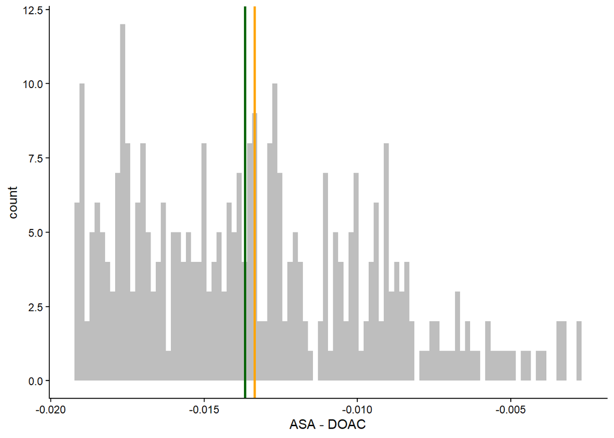

Figure 4.1: Distribution of risk difference for all study participants. Mean risk difference in orange. Median in green.

Table 4.6: Estimated average adjusted risk difference, along with corresponding p-value and confidence interval.

| contrast | estimate | SE | p.value | 95CI_low | 95CI_high |
| --- | --- | --- | --- | --- | --- |
| ASA - DOAC | -0.013 | 0.046 | 0.769 | -0.103 | 0.076 |

Table 4.7: Estimated average adjusted risk ratio, along with corresponding p-value and confidence interval.

| contrast | estimate | p.value | 95CI_low | 95CI_high |
| --- | --- | --- | --- | --- |
| ASA/DOAC | 0.948 | 0.769 | 0.662 | 1.357 |

## 4.2 Primary safety endpoint

### 4.2.1 Descriptive statistics

Table 4.8: Descriptive statistics for primary safety endpoint. Counts and proportions. The counts are the number of participants experiencing an event of a particular type as their *first* safety event. Some patients may experience more than one safety event.

[output not shown]

Out of the 31 safety events, 10 happen in patients that also switch between the treatments at some point. Among these 10 patients: 6 experience the safety event before switching, while 4 experience the safety event after switching.

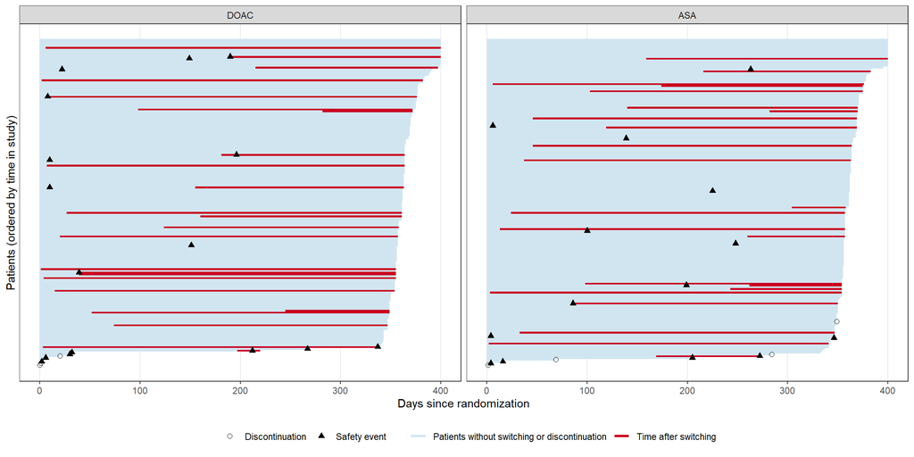

Figure 4.2: All patients

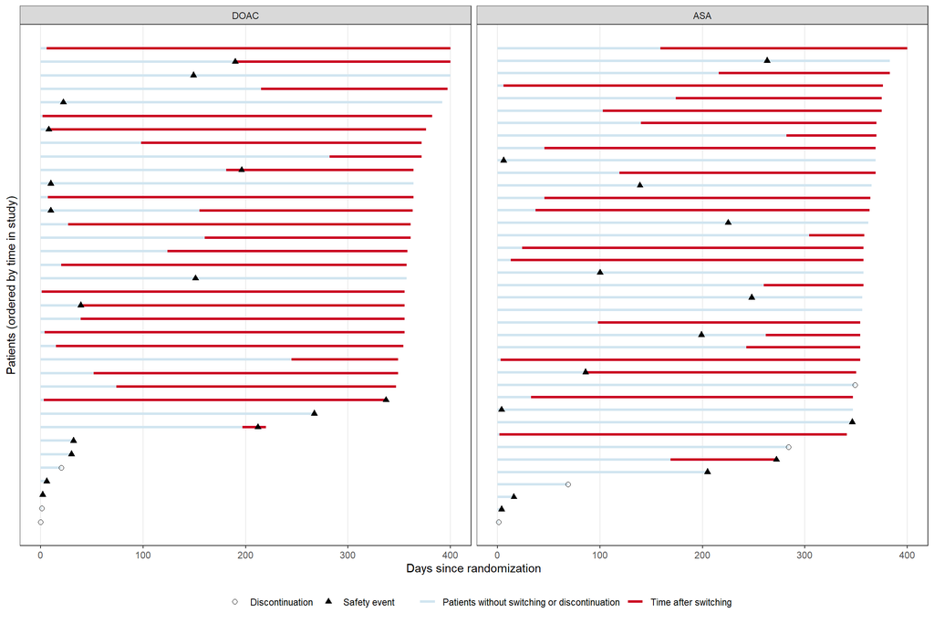

Figure 4.3: Patients with safety events and/or switching and discontinuation

### 4.2.2 Unadjusted analysis with multiple imputation, treatment policy strategy

Multiple imputation with imputation model containing no covariates (so using only the overall event rate, to stay more or less in-line with the protocol). The analysis model uses the treatment variable and no other covariates.

Table 4.9: Estimated average unadjusted risk difference, along with corresponding p-value and confidence interval.

| contrast | estimate | SE | p.value.nonsup | 95CI_low | 95CI_high |
| --- | --- | --- | --- | --- | --- |
| DOAC - ASA | 0.006 | 0.031 | 0.000 | -0.055 | 0.067 |

### 4.2.3 Unadjusted analysis, complete-cases, treatment policy strategy

Discuss margin (in protocol it says 11.9%, but that seems a bit wide maybe)

Table 4.10: Estimated average unadjusted risk difference, along with corresponding p-value (for non-inferiority test) and confidence interval.

| contrast | estimate | SE | p.value.nonsup | 95CI_low | 95CI_high |
| --- | --- | --- | --- | --- | --- |
| DOAC - ASA | 0.006 | 0.031 | 0.000 | -0.054 | 0.067 |

# 5 Key secondary endpoints

## 5.1 Clinical efficacy

## 5.2 Thromboembolic events

## 5.3 Bleeding events

## 5.4 All-cause mortality

# 6 Secondary safety endpoints

# 7 Additional safety analysis

> Which numbers and tables do you want to see here?

## 7.1 Overview of adverse events, serious adverse events and suspected unexpected serious adverse reaction

Table 7.1: Summary of adverse events.

|  | DOAC (n=180) | ASA (n=180) | Overall (n=360) |
| --- | --- | --- | --- |
| Number of AEs | 260 | 255 | 515 |
| Number of patients with any AEs | 119 (66.1%) | 114 (63.3%) | 233 (64.7%) |
| Number of patients with one AE | 56 (31.1%) | 43 (23.9%) | 99 (27.5%) |
| Number of patients with two AE | 27 (15%) | 41 (22.8%) | 68 (18.9%) |
| Number of patients with three or more AEs | 36 (20%) | 30 (16.7%) | 66 (18.3%) |
| Number of SAEs | 124 | 113 | 237 |
| Number of patients with any SAEs | 72 (40%) | 67 (37.2%) | 139 (38.6%) |
| Number of SUSARs | 8 | 1 | 9 |
| Number of patients with any SUSARs | 8 (4.4%) | 1 (0.6%) | 9 (2.5%) |

## 7.2 Maximal intensity and causal relationships of AEs and SAEs to acetylsalicylic acid

Table 7.2: Number of adverse events by categories of intensity and causal relationship to acetylsalicylic acid.

| intensity | Unrelated | Unlikely | Possible | Probable | Definite |
| --- | --- | --- | --- | --- | --- |
| Mild | 15 | 43 | 20 | 5 | 0 |
| Moderate | 40 | 24 | 14 | 6 | 0 |
| Severe | 33 | 13 | 13 | 5 | 0 |

## 7.3 Maximal intensity and causal relationships of AEs and SAEs to apixaban

Table 7.3: Number of adverse events by categories of intensity and causal relationship to apixaban.

| intensity | Unrelated | Unlikely | Possible | Probable | Definite |
| --- | --- | --- | --- | --- | --- |
| Mild | 14 | 33 | 19 | 4 | 0 |
| Moderate | 12 | 15 | 7 | 3 | 0 |
| Severe | 15 | 7 | 8 | 1 | 0 |

## 7.4 Maximal intensity and causal relationships of AEs and SAEs to edoxaban

Table 7.4: Number of adverse events by categories of intensity and causal relationship to edoxaban.

| intensity | Unrelated | Unlikely | Possible | Probable | Definite |
| --- | --- | --- | --- | --- | --- |
| Mild | 2 | 13 | 27 | 7 | 0 |
| Moderate | 12 | 21 | 7 | 4 | 0 |
| Severe | 12 | 8 | 3 | 0 | 0 |

## 7.5 Maximal intensity and causal relationships of AEs and SAEs to rivaroxaban

Table 7.5: Number of adverse events by categories of intensity and causal relationship to rivaroxaban.

| intensity | Unrelated | Unlikely | Possible | Probable | Definite |
| --- | --- | --- | --- | --- | --- |
| Mild | 0 | 3 | 5 | 2 | 0 |
| Moderate | 3 | 3 | 3 | 3 | 0 |
| Severe | 1 | 1 | 0 | 0 | 0 |

## 7.6 Adverse Events by System Organ Class and Preferred term

Table 7.6: Number of AEs and SAEs by system organ class and preferred term.

| System organ class | Preferred term | AE DOAC | AE ASA | SAE DOAC | SAE ASA |
| --- | --- | --- | --- | --- | --- |
| blood and lymphatic system disorders | anaemia | 1 | 3 | 0 | 2 |
|  | haemolytic anaemia | 0 | 0 | 0 | 1 |
|  | iron deficiency anaemia | 0 | 0 | 1 | 0 |
| cardiac disorders | acute coronary syndrome | 0 | 0 | 0 | 1 |
|  | acute myocardial infarction | 0 | 0 | 2 | 1 |
|  | angina pectoris | 1 | 0 | 0 | 0 |
|  | atrial fibrillation | 11 | 16 | 2 | 2 |
|  | atrial flutter | 3 | 0 | 0 | 0 |
|  | atrioventricular block | 1 | 1 | 2 | 2 |
|  | atrioventricular block complete | 1 | 0 | 4 | 2 |
|  | atrioventricular block first degree | 0 | 0 | 1 | 0 |
|  | atrioventricular block second degree | 0 | 0 | 2 | 1 |
|  | cardiac arrest | 0 | 0 | 1 | 3 |
|  | cardiac failure | 3 | 1 | 7 | 5 |
|  | myocardial infarction | 0 | 0 | 0 | 1 |
|  | nodal rhythm | 1 | 0 | 1 | 0 |
|  | pericardial effusion | 0 | 1 | 1 | 0 |
|  | pericarditis | 0 | 0 | 0 | 1 |
|  | ventricular arrhythmia | 0 | 0 | 1 | 0 |
|  | ventricular tachycardia | 1 | 0 | 2 | 0 |
| ear and labyrinth disorders | sudden hearing loss | 0 | 1 | 0 | 0 |
|  | vertigo positional | 1 | 0 | 1 | 0 |
| endocrine disorders | hypothyroidism | 0 | 1 | 0 | 0 |
| eye disorders | amaurosis fugax | 4 | 0 | 1 | 3 |
|  | blindness | 0 | 1 | 0 | 0 |
|  | conjunctival haemorrhage | 0 | 1 | 0 | 0 |
|  | diplopia | 1 | 1 | 0 | 0 |
|  | vision blurred | 1 | 1 | 0 | 0 |
|  | visual impairment | 2 | 3 | 0 | 0 |
|  | vitreous haemorrhage | 0 | 0 | 0 | 2 |

[output cut: 166 more lines]